# Presentation Ninja

⚔ with xaringan

Yihui Xie

2016/12/12 (updated: 2019-04-22)

# Learning Objectives

## Objectives

Learn how to use R to detect candle stick patterns.

- doji (1-day pattern)
- hammer (2-day pattern)
- engulfing (2-day pattern)
- harami (2-day pattern)
- kicking (2-day pattern)
- reversal (2-day pattern)
- three-in-a-row (3-day pattern)
- star (3-day pattern)
- three method (5-day pattern)

## Setup

We use Microsoft (ticker: MSFT) to do demonstration

```r
getSymbols("MSFT")
```

# Terminology

## Candle Stick

Four data points: high, low, open, close

- Two ends: high and low
- Body: close and open
- Upper Shadow: line between high and real body
- Lower Shadow: line between low and real body

Color:

- Bullish Candle: close > open (green or white)
- Bearish Candle: close < open (red or black)

## Lengths

Upper shadow length

$$US(t)=Hi(t)-\max\{Op(t),Cl(t)\}$$

Lower shadow length

$$LS(t)=\min\{Op(t),Cl(t)\}-Lo(t)$$
Whole candle length

$$WC(t)=Hi(t)-Lo(t)$$

Body length

$$BL(t)= |Op(t)-Cl(t)|$$

## Size of body length

Compare with whole candle length:

- small body: $\delta WC(t) > BL(t)$ for small $\delta=0.1$
- large body: $\delta WC(t) < BL(t)$ for large $\delta=0.9$

## Size of shadow

Compare with whole candle length:

- short upper shadow: $\delta WC(t) > US(t)$ for small $\delta=0.1$
- long upper shadow: $\delta WC(t) < US(t)$ for large $\delta=0.9$

## Size of candle length

Compare with historical whole candle lengths:

- small body: $WC(t) < \delta \times median\{WC(t-1),...,WC(t-n-1)\}$ for parameter $\delta=1$
- large body: $WC(t) > \delta \times median\{WC(t-1),...,WC(t-n-1)\}$ for parameter $\delta=1$

Similar ideas can be extended to body length and shadow sizes.

## Price Movement

Daily

- Up: $U(t)=1 \text{ if } Cl(t)>Op(t)$ and 0 otherwise
- Down: $D(t)=1 \text{ if } Cl(t)<Op(t)$ and 0 otherwise

Inter-day Gap

# Doji (1-day pattern)

## Doji (Japanese: Crux)

Indecision signal: up and down forces are balanced

1. long candle stick (High >> Low)
2. narrow real body (Close ~ Open)

## Example

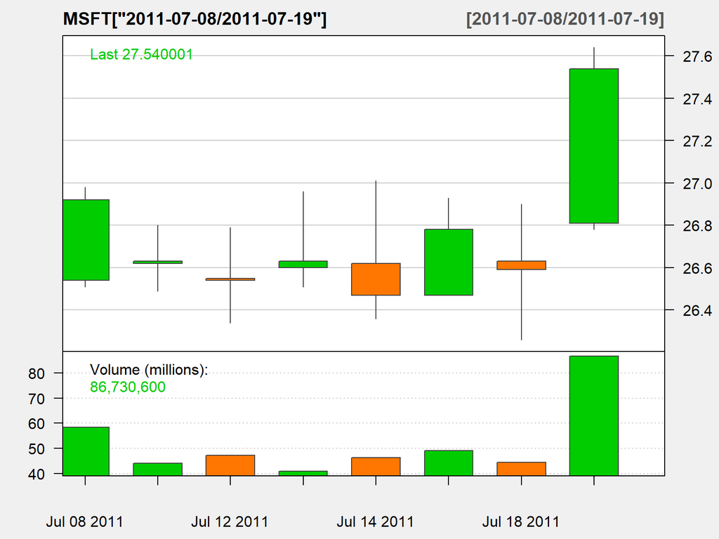

```r
candleChart(MSFT['2011-07-08/2011-07-19'],theme='white')
```

## Code

```r
delta <-0.1
doji <- c()
WC <- Hi(MSFT) - Lo(MSFT)
BL <- abs(Op(MSFT) - Cl(MSFT))
for (i in 1:length(Cl(MSFT))){
  if (delta *WC[i]>BL[i]){
    doji[i] <- 1
  } else{
    doji[i] <- 0
  }
}
doji <- reclass(doji,Cl(MSFT))
```

## Check result

```r
doji['2011-07-08/2011-07-19']
```

```
##            [,1]
## 2011-07-08    0
## 2011-07-11    1
## 2011-07-12    1
## 2011-07-13    1
## 2011-07-14    0
## 2011-07-15    0
## 2011-07-18    1
## 2011-07-19    0
```

## Dragonfly Doji

Bullish signal: resist downward pressure

1. long candle stick + narrow real body (Doji)
2. short upper shadow (High ~ Close ~ Open)

## Example

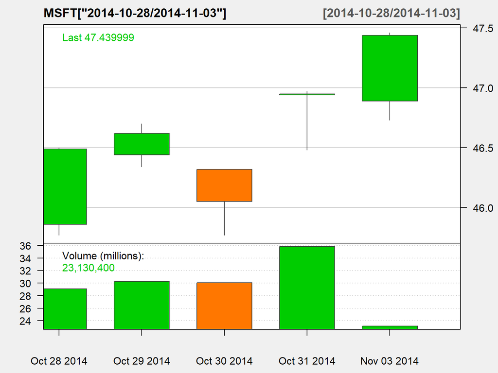

```r
candleChart(MSFT['2014-10-28/2014-11-03'],theme='white')
```

## Code

```r
delta <-0.1
d.doji <- c()
WC <- Hi(MSFT) - Lo(MSFT)
US <- Hi(MSFT) -pmax(Op(MSFT), Cl(MSFT))
for (i in 1:length(Cl(MSFT))){
  if (delta*WC[i]>US[i] &&
      doji[i]==1){
    d.doji[i] <- 1
  } else{
    d.doji[i] <- 0
  }
}
d.doji <- reclass(d.doji,Cl(MSFT))
```

- Note that pmax is used as we do pairwise max.

## Check result

```r
d.doji['2014-10-28/2014-11-03']
```

```
##            [,1]
## 2014-10-28    0
## 2014-10-29    0
## 2014-10-30    0
## 2014-10-31    1
## 2014-11-03    0
```

## Gravestone Doji

1. Doji (long candle stick + narrow real body)
2. Low ~ Close ~ Open (short lower shadow)

## Example

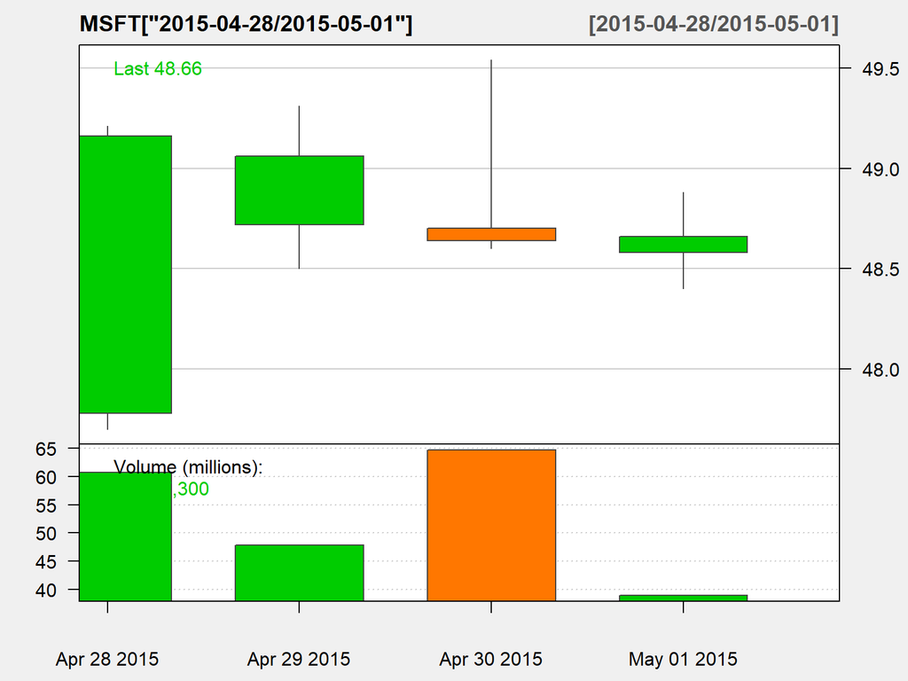

```r
candleChart(MSFT['2015-04-28/2015-05-01'], theme='white')
```

## Exercise

- Write the code to identify gravestone doji.
- Check your code with the graph in the Example.

# Hammers (2-day pattern)

## Hammer and Hang Man

Reversal signal:

1. Short upper shadow
2. Long lower shadow
- Hammer: Bullish signal in a downward trend
- Hang Man: Bearish signal in a upward trend

## Example

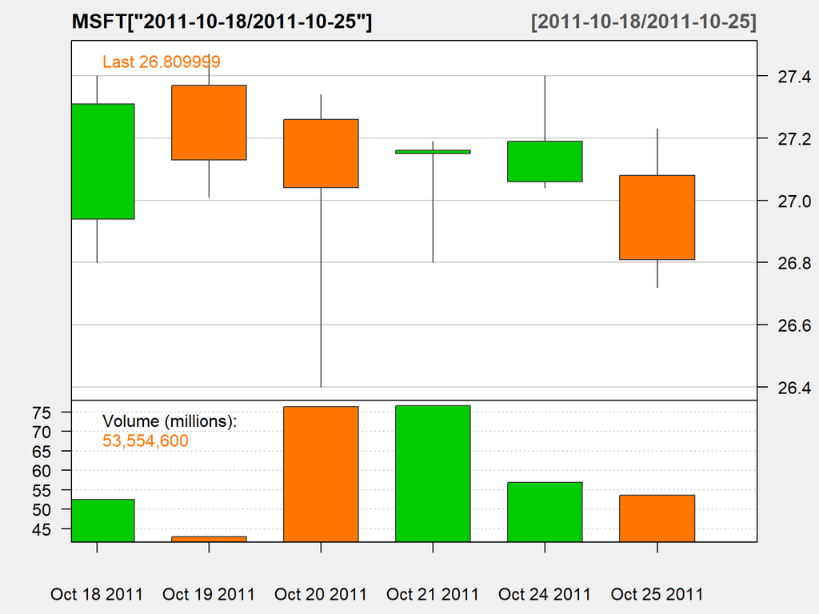

```r
candleChart(MSFT['2011-10-18/2011-10-25'], theme='white')
```

## Code

```r
delta1 <- 0.1
delta2 <- 0.7
hammer <-c()
WC <- Hi(MSFT) - Lo(MSFT)
US <- Hi(MSFT) - pmax(Op(MSFT), Cl(MSFT))
LS <- pmin(Op(MSFT), Cl(MSFT)) - Lo(MSFT)
for (i in 1:length(Cl(MSFT))){
  if (delta1*WC[i]>US[i] && delta2*WC[i]<LS[i]){
    hammer[i] <- 1
  } else{
    hammer[i] <- 0
  }
}
hammer <- reclass(hammer,Cl(MSFT))
```

## Verification

```r
hammer['2011-10-18/2011-10-25']
```

```
##            [,1]
## 2011-10-18    0
## 2011-10-19    0
## 2011-10-20    0
## 2011-10-21    1
## 2011-10-24    0
## 2011-10-25    0
```

## Inverted Harmer and Shooting Stars

Reversal signal:

1. Long upper shadow
2. Short lower shadow
- Inverted Harmer: Bullish signal in a downward trend
- Shooting Stars: Bearish signal in a upward trend

## Example

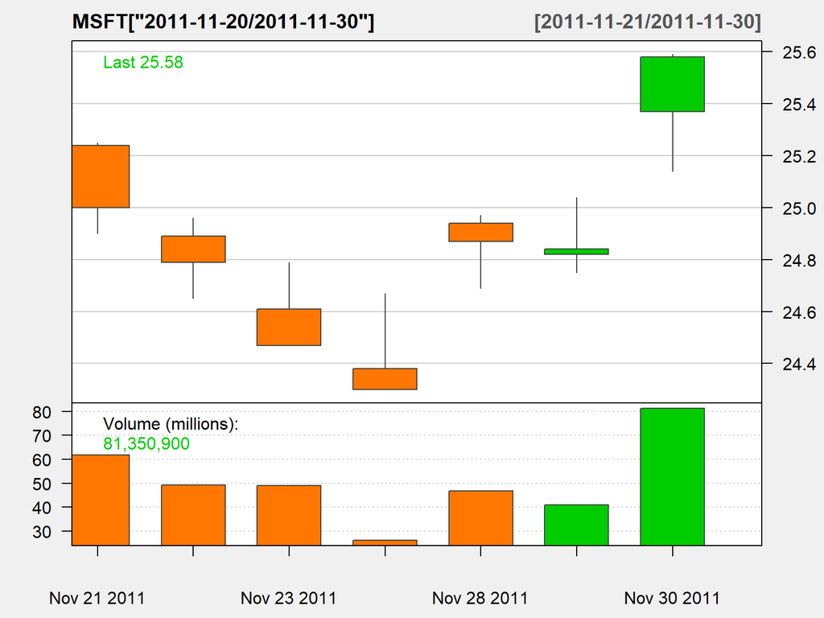

```r
candleChart(MSFT['2011-11-20/2011-11-30'], theme='white')
```

## Exercise

- Write the code to identify inverted harmer or shooting stars.
- Check your code with the graph in the Example.

# Engulfing Patterns (2-day pattern)

## Bullish Engulfing

Bullish signal as bullish force dominates:

1. Bearish Candle on Day 1
2. Bullish Candle on Day 2
3. Real body of Day 1 Candle within that of Day 2.

## Example

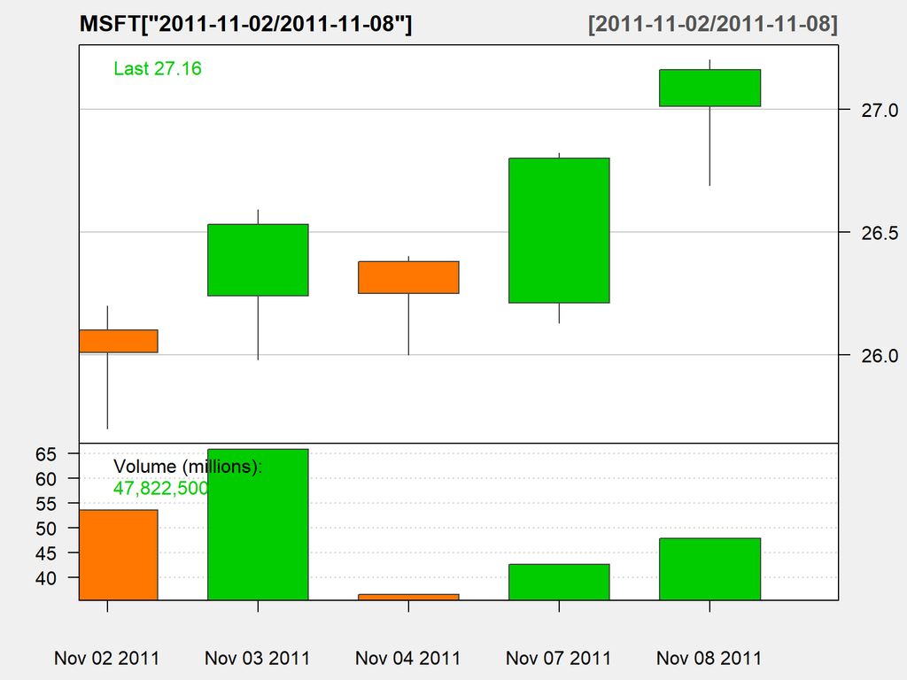

```r
candleChart(MSFT['2011-11-02/2011-11-08'], theme='white')
```

## Code

```r
engulf <-c(NA)
OP <- as.numeric(Op(MSFT))
CL <- as.numeric(Cl(MSFT))

U <- ifelse(OP < CL,1,0)
D <- ifelse(OP > CL,1,0)

for (i in 2:length(Cl(MSFT))){
  if (D[i-1]>0 &&
      U[i]>0 &&
      OP[i]<=CL[i-1] &&
      CL[i]>=OP[i-1]){
    engulf[i] <- 1
  } else{
    engulf[i] <- 0
  }
}
engulf <- reclass(engulf,Cl(MSFT))
```

## Verification

```r
engulf['2011-11-02/2011-11-08']
```

```
##            [,1]
## 2011-11-02    0
## 2011-11-03    0
## 2011-11-04    0
## 2011-11-07    1
## 2011-11-08    0
```

## Bearish Enguling

Bearish signal as bearish force dominates:

1. Bullish Candle on Day 1
2. Bearish Candle on Day 2
3. Real body of Day 1 Candle within that of Day 2.

## Example

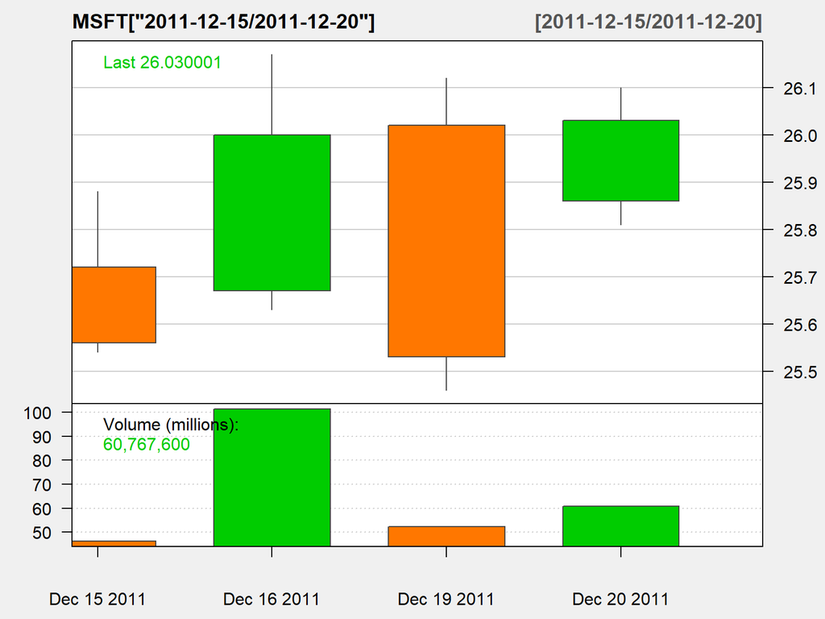

```r
candleChart(MSFT['2011-12-15/2011-12-20'], theme='white')
```

## Exercise

- Write the code to identify bearish engulfing.
- Check your code with the graph in the Example.

# Harami (Pregnant:2-day pattern)

## Bullish Harami

Bullish signal as bullish force fights back:

1. Large Bearish Candle on Day 1
2. Small Bullish Candle on Day 2
3. Real body of Day 2 Candle within that of Day 1.

## Example

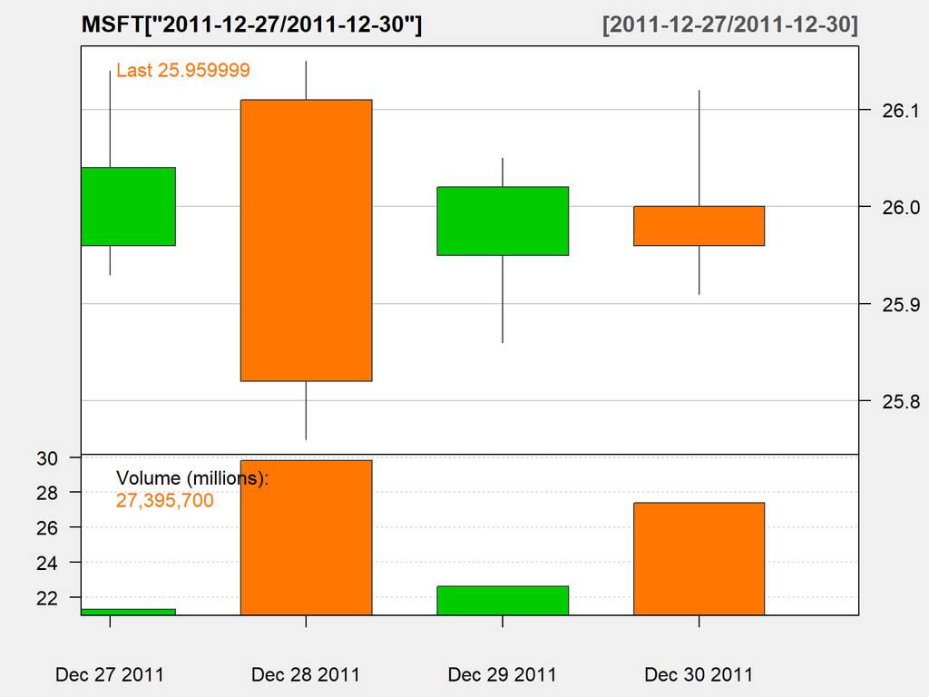

```r
candleChart(MSFT['2011-12-27/2011-12-30'], theme='white')
```

## Code

```r
harami <-c(NA)
OP <- as.numeric(Op(MSFT))
CL <- as.numeric(Cl(MSFT))

U <- ifelse(OP < CL,1,0)
D <- ifelse(OP > CL,1,0)

for (i in 2:length(Cl(MSFT))){
  if (D[i-1]>0 &&
      U[i]>0 &&
      OP[i]>=CL[i-1] &&
      CL[i]<=OP[i-1]){
    harami[i] <- 1
  } else{
    harami[i] <- 0
  }
}
harami <- reclass(harami,Cl(MSFT))
```

## Verification

```r
harami['2011-12-27/2011-12-30']
```

```
##            [,1]
## 2011-12-27    0
## 2011-12-28    0
## 2011-12-29    1
## 2011-12-30    0
```

## Bearish Harami

Bearish signal as bearish force fights back

1. Large Bullish Candle on Day 1
2. Small Bearish Candle on Day 2
3. Real body of Day 2 Candle within that of Day 1.

## Example

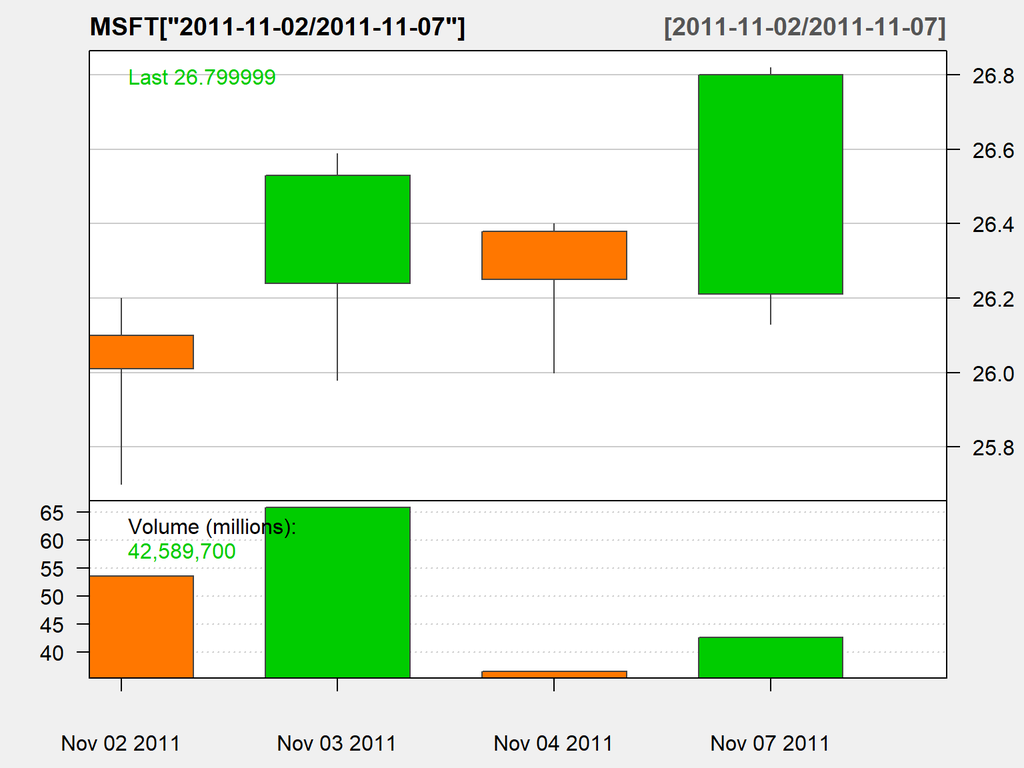

```r
candleChart(MSFT['2011-11-02/2011-11-07'], theme='white')
```

## Exercise

- Write the code to identify bearish harami
- Check your code with the graph in the Example.

# Median Reversal (2-day pattern)

## Piercing Line

Bullish signal

1. Bearish candle on day 1
2. Bullish candle on day 2
3. Close on day 2 > mid point of day 1 body

## Example

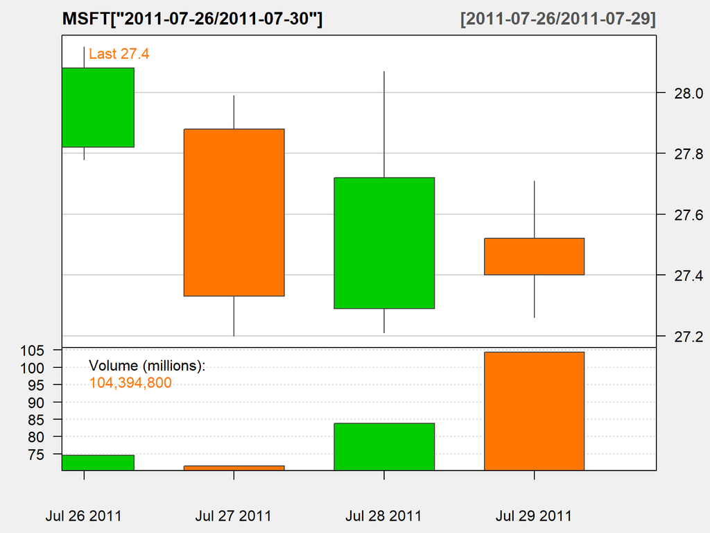

```r
candleChart(MSFT['2011-07-26/2011-07-30'], theme='white')
```

## Code

```r
pierce <-c(NA)
OP <- as.numeric(Op(MSFT))
CL <- as.numeric(Cl(MSFT))

U <- ifelse(OP < CL,1,0)
D <- ifelse(OP > CL,1,0)
M <- (OP+CL)/2

for (i in 2:length(Cl(MSFT))){
  if (D[i-1]>0 &&
      U[i]>0 &&
      CL[i]>=M[i-1]){
    pierce[i] <- 1
  } else{
    pierce[i] <- 0
  }
}
pierce <- reclass(pierce,Cl(MSFT))
```

## Verification

```r
pierce['2011-07-26/2011-07-30']
```

```
##            [,1]
## 2011-07-26    0
## 2011-07-27    0
## 2011-07-28    1
## 2011-07-29    0
```

## Dark cloud cover

1. Bullish candle on day 1
2. Bearish candle on day 2
3. Close on day 2 < mid point of day 1 body

## Example

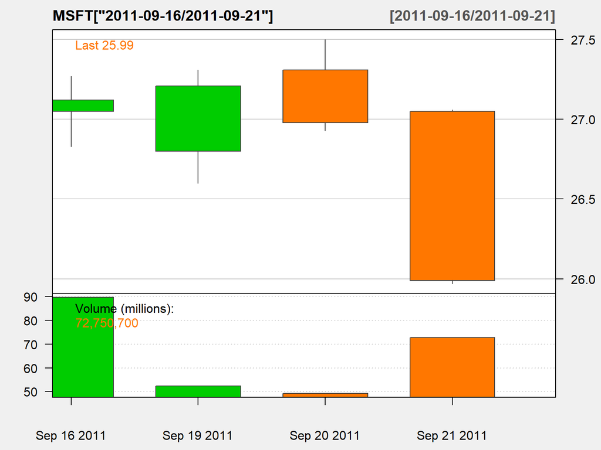

```r
candleChart(MSFT['2011-09-16/2011-09-21'], theme='white')
```

## Exercise

- Write the code to identify dark cloud cover
- Check your code with the graph in the Example.

# Two in a row

## Kicking up

Bullish signal:

1. bearish candle on day 1
2. bullish candle on day 2
3. gap up between day 1 and day 2

## Example

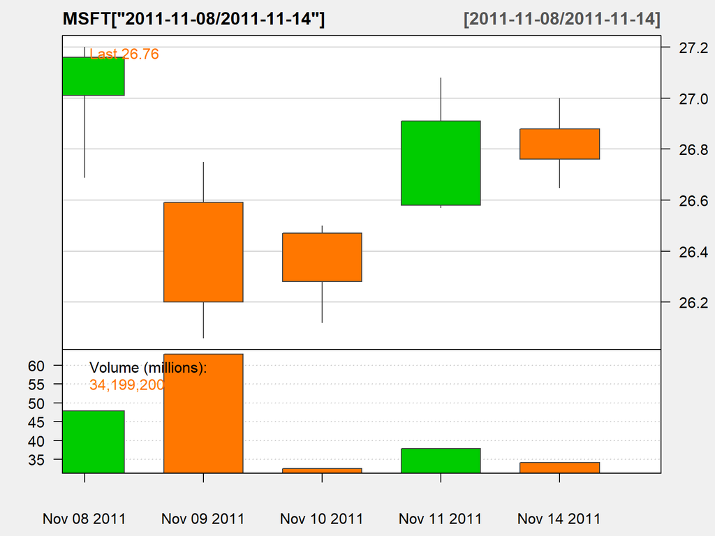

```r
candleChart(MSFT['2011-11-08/2011-11-14'], theme='white')
```

## Code

```r
kick.up <-c(NA)
OP <- as.numeric(Op(MSFT))
CL <- as.numeric(Cl(MSFT))

U <- ifelse(OP < CL,1,0)
D <- ifelse(OP > CL,1,0)

for (i in 2:length(Cl(MSFT))){
  if (D[i-1]>0 &&
      U[i]>0 &&
      OP[i]>=CL[i-1]){
    kick.up [i] <- 1
  } else{
    kick.up[i] <- 0
  }
}
kick.up <- reclass(kick.up,Cl(MSFT))
```

## Verification

```r
kick.up['2011-11-08/2011-11-14']
```

```
##            [,1]
## 2011-11-08    0
## 2011-11-09    0
## 2011-11-10    0
## 2011-11-11    1
## 2011-11-14    0
```

## Kicking Down

Bearish signal:

1. bullish candle on day 1
2. bearish candle on day 2
3. gap down between day 1 and day 2

## Example

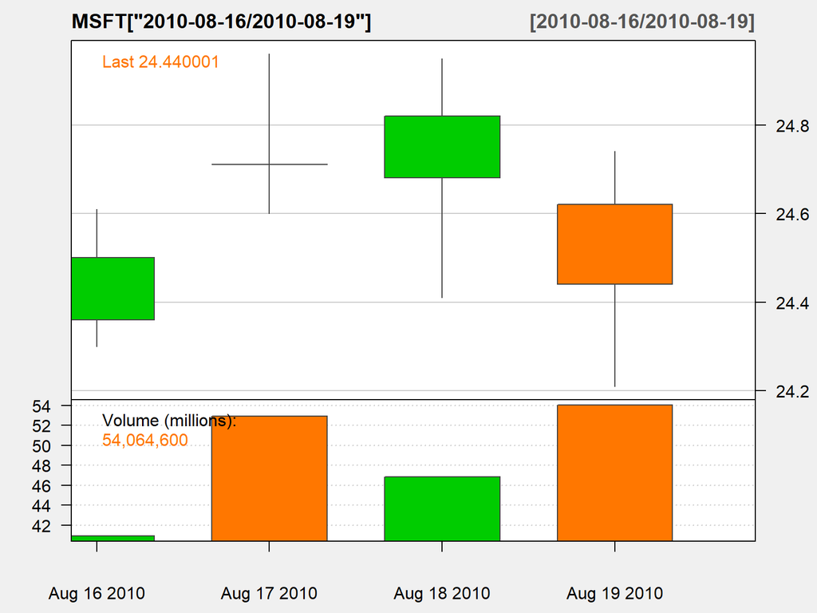

```r
candleChart(MSFT['2010-08-16/2010-08-19'], theme='white')
```

## Exercise

- Write the code to identify kick down.
- Check your code with the graph in the Example.

# Appendix: Multi-day patterns

# Three in a row (3-day pattern)

## Three white solders

Bullish signal:

1. Large bullish candles for 3 days
2. Open prices are rising for 3 days
3. Close prices are rising for 3 days

## Example

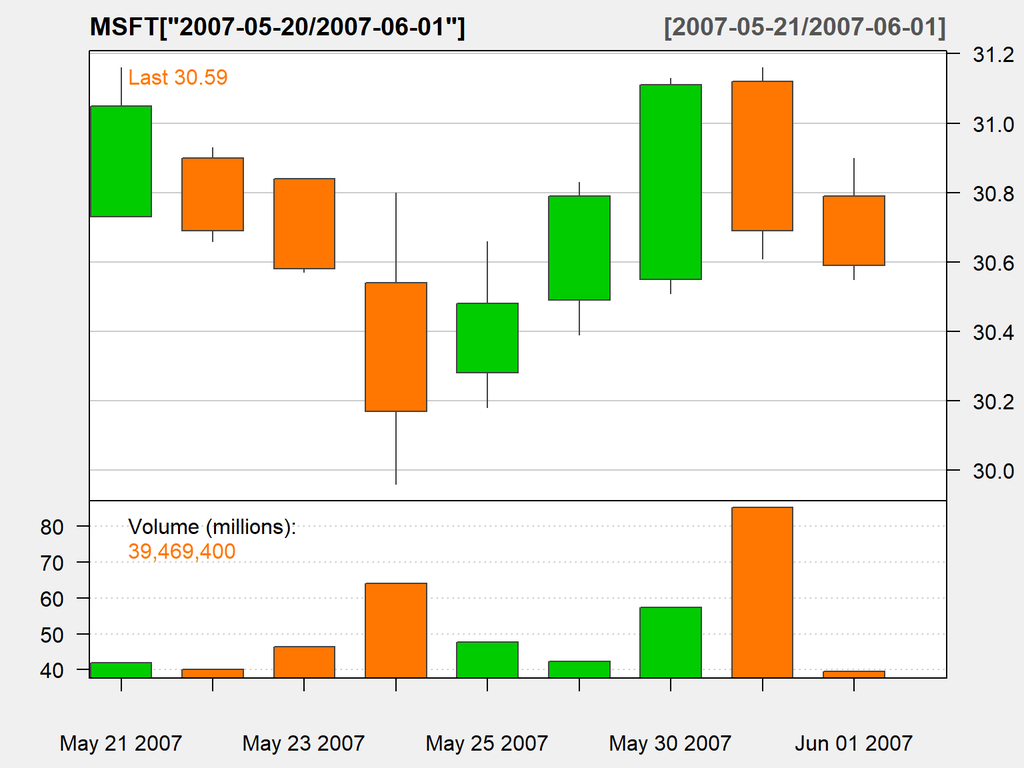

```r
candleChart(MSFT['2007-05-20/2007-06-01'], theme='white')
```

## Three Black Crows

Bearish signal:

1. Large bearish candles for 3 days
2. Open prices are dropping for 3 days
3. Close prices are dropping for 3 days

## Example

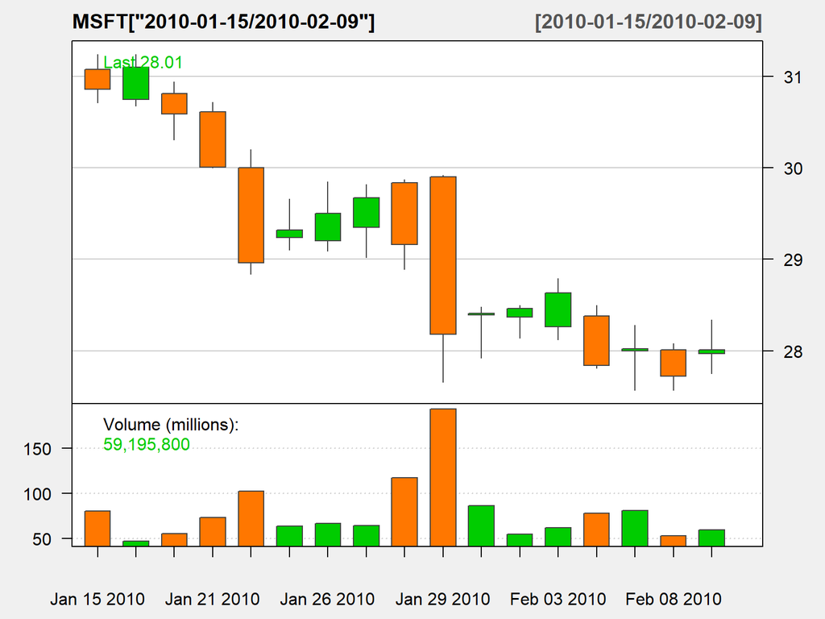

```r
candleChart(MSFT['2010-01-15/2010-02-09'], theme='white')
```

# Star (3-day pattern)

## Morning star

Bullish signal:

1. Large bearish candle on day 1
2. Small candle (or doji) on day 2
3. Large bullish candle on day 3
4. Gap down between day 1 and day 2
5. Gap up between day 2 and day 3

## Example

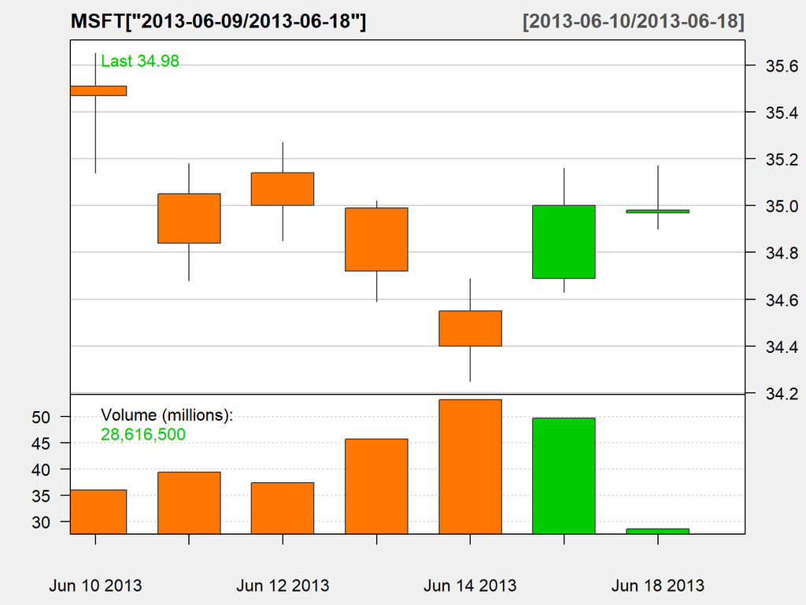

```r
candleChart(MSFT['2013-06-09/2013-06-18'], theme='white')
```

## Evening Star

Bearish Signal:

1. Large **bullish** candle on day 1
2. Small candle (or doji) on day 2
3. Large **bearish** candle on day 3
4. **Gap up** between day 1 and day 2
5. **Gap down** between day 2 and day 3

## Example

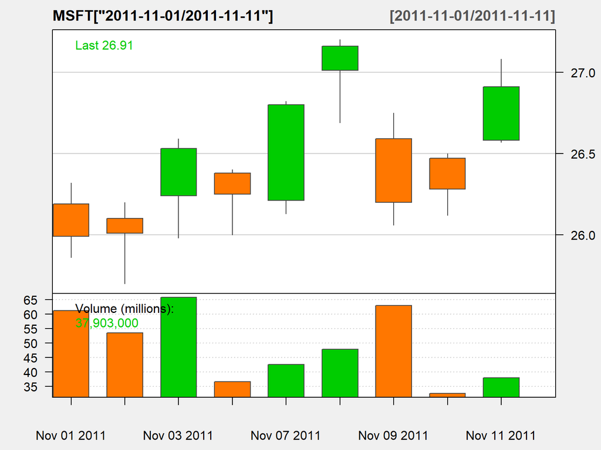

```r
candleChart(MSFT['2011-11-01/2011-11-11'], theme='white')
```

# Three Methods (5-day pattern)

## Rising Three

Bullish signal:

1. Large bullish candle on day 1
2. (small) bearish candles for next 3 days
3. Large bullish candle on day 5
4. Day 1 low is lowest
5. Day 5 high is highest

## Example

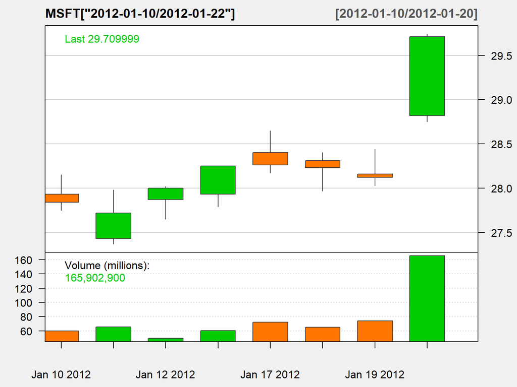

```r
candleChart(MSFT['2012-01-10/2012-01-22'], theme='white')
```

## Falling three

Bearish signal:

1. Large bearish candle on day 1
2. (small) bullish candles for next 3 days
3. Large bearish candle on day 5
4. Day 1 high is the highest
5. Day 5 low is the lowest

## Exercise

Can you find an example?

## Appendix: CandleStickPattern Package

To install this package, it is the easist to use devtools:

```r
#install.packages("devtools")
library(devtools)
```

Then we can use the `install_github` to get the package directly:

```r
#install_github("kochiuyu/CandleStickPattern")
library(CandleStickPattern)
```

This package directly determines the pattern.

- [Github](https://github.com/kochiuyu/CandleStickPattern)
- [Manual](http://htmlpreview.github.io/?https://github.com/kochiuyu/CandleStickPattern/blob/master/vignettes/CandleStick.html)